# Factors Impacting Life Expectancy

# Introduction

This project will research factors that might predict life expectancy across multiple regions globally. It is generally accepted that developed countries have lower mortality and higher lifespan than their less-developed peers. But how true is this assumption? And if these countries do indeed have lower mortality, which factors are most responsible?

Developed countries tend to have more resources, better nutrition standards and access to advanced medical infrastructure, all of which facilitate longevity. However, it shouldn’t be assumed that all aspects of development are positive. Many developed countries are more likely to suffer from higher rates of obesity or alcoholism, counteracting their advantages in nutrition and medicine. Moreover, the complex economies of developed countries may result in more stressful lifestyles, further harming mortality.

Buddhist monks live in Nepal don’t spend their sleeping time on swiping phones, breath car exhaust, or eat packaged food full of chemicals. It’s true Nepal’s GDP is far behind US, but do US residents live longer than Nepal people necessarily? Hopefully data analysis with this data set can shed some light.

## Setup

```r
# Set default CRAN mirror and install required packages
options(repos = c(CRAN = "https://cloud.r-project.org"))

required_packages <- c("tseries", "lmtest", "car", "glmnet", "caret", "readr", "knitr")
new_packages <- required_packages[!(required_packages %in% installed.packages()[,"Package"])]
if (length(new_packages)) install.packages(new_packages, dependencies = TRUE)
```

## Description of the data set

For this project we propose using the `Life Expectancy (WHO)` data set which is available [here](https://www.kaggle.com/datasets/kumarajarshi/life-expectancy-who). The data is an amalgamation of two sources. The primary source is The Global Health Observatory (GHO) repository, which is maintained by the World Health Organization (WHO) for the purpose of tracking demographic and health factors impacting mortality. The data spans 193 countries and 15 years, from 2000 to 2015. This dataset is supplemented with United Nations economic data. The resulting dataset will enable us to assess the impact of immunization, economic and social factors on mortality.

The dataset was compiled by Deeksha Russel and Duan Wang. It is a curated subset of the Global Health Observatory database, with only those variables deemed most critical and representative being retained in the file dataset. The dataset has also been cleaned to remove countries for which data was incomplete.

```r
library(readr)
data = read_csv('./data/life_expectancy.csv', show_col_types = FALSE)
head(data)
```

```
## # A tibble: 6 × 22
##   Country      Year Status   `Life expectancy` `Adult Mortality` `infant deaths`
##   <chr>       <dbl> <chr>                <dbl>             <dbl>           <dbl>
## 1 Afghanistan  2015 Develop…              65                 263              62
## 2 Afghanistan  2014 Develop…              59.9               271              64
## 3 Afghanistan  2013 Develop…              59.9               268              66
## 4 Afghanistan  2012 Develop…              59.5               272              69
## 5 Afghanistan  2011 Develop…              59.2               275              71
## 6 Afghanistan  2010 Develop…              58.8               279              74
## # ℹ 16 more variables: Alcohol <dbl>, `percentage expenditure` <dbl>,
## #   `Hepatitis B` <dbl>, Measles <dbl>, BMI <dbl>, `under-five deaths` <dbl>,
## #   Polio <dbl>, `Total expenditure` <dbl>, Diphtheria <dbl>, `HIV/AIDS` <dbl>,
## #   GDP <dbl>, Population <dbl>, `thinness  1-19 years` <dbl>,
## #   `thinness 5-9 years` <dbl>, `Income composition of resources` <dbl>,
## #   Schooling <dbl>
```

There are 22 columns and 2938 records in the CSV file. `Life expectancy` will be used as the response variable, and the rest are predictor candidates.

| Name | Definition |
| --- | --- |
| country | country |
| year | year |
| status | Developed or Developing |
| life expectancy | life expectancy in age |
| adult mortality | Adult Mortality Rates of both sexes (probability of dying between 15 and 60 years per 1000 population) |
| infant deaths | Number of Infant Deaths per 1000 population |
| alcohol | Alcohol, recorded per capita (15+) consumption (in litres of pure alcohol) |
| percentage expenditure | Expenditure on health as a percentage of Gross Domestic Product per capita (%) |
| Hepatitis B | Hepatitis B (HepB) immunization coverage among 1-year-olds (%) |
| Measles | Measles - number of reported cases per 1000 population |
| BMI | Average Body Mass Index of entire population |
| under-five deaths | Number of under-five deaths per 1000 population |
| Polio | Polio (Pol3) immunization coverage among 1-year-old (%) |
| total expenditure | General government expenditure on health as a percentage of total government expenditure (%) |
| Diphtheria | Diphtheria tetanus toxoid and pertussis (DTP3) immunization coverage among 1-year-olds (%) |
| HIV/AIDS | Deaths per 1 000 live births HIV/AIDS (0-4 years) |
| GDP | Gross Domestic Product per capita (in USD) |
| Population | Population of the country |
| thinness 1-19 years | Prevalence of thinness among children and adolescents for Age 10 to 19 (% ) |
| thinness 5-9 years | Prevalence of thinness among children for Age 5 to 9(%) |
| income composition | Human Development Index in terms of income composition of resources (index ranging from 0 to 1) |
| schooling | Number of years of Schooling(years) |

# Methods

## Data Cleaning

Original variable names are not r-friendly. We will rename them to follow snake case for easy access on further analysis.

- rename variables
- convert category variables to factors
- filter records based on column values
- omit NA values

```r
names(data)[names(data) == "Country"] = "country"
names(data)[names(data) == "Year"] = "year"
names(data)[names(data) == "Status"] = "status"
names(data)[names(data) == "Life expectancy"] = "life_expectancy"
names(data)[names(data) == "Adult Mortality"] = "adult_mortality"
names(data)[names(data) == "infant deaths"] = "infant_deaths"
names(data)[names(data) == "Alcohol"] = "alcohol"
names(data)[names(data) == "percentage expenditure"] = "percent_exp"
names(data)[names(data) == "Hepatitis B"] = "hepatitis"
names(data)[names(data) == "measles"] = "measles"
names(data)[names(data) == "under-five deaths"] = "under_5_deaths"
names(data)[names(data) == "Polio"] = "polio"
names(data)[names(data) == "Total expenditure"] = "total_exp"
names(data)[names(data) == "Diphtheria"] = "diphtheria"
names(data)[names(data) == "HIV/AIDS"] = "hiv_aids"
names(data)[names(data) == "Population"] = "population"
names(data)[names(data) == "thinness  1-19 years"] = "thinness_1_19"
names(data)[names(data) == "thinness 5-9 years"] = "thinness_5_9"
names(data)[names(data) == "Income composition of resources"] = "HBI"
names(data)[names(data) == "Schooling"] = "schooling"

data$country = as.factor(data$country)
data$year = as.factor(data$year)
data$status = as.factor(data$status)

data = subset(data, percent_exp > 0)
data = subset(data, hiv_aids > 0)
data = subset(data, GDP > 0)
data = na.omit(data)
```

## Identify Potential Transformations and Collinearity

For this analysis we intend to perform linear regression with multiple predictors. However, we need to verify that our predictors are independent, which is a core assumption of the linear regression model. If multiple predictors in our model are correlated, it will harm our ability to determine the impact of each predictor on the response variable, since any change to the collinear predictors will exert an outsized influence on the response variable. Collinear variables will also increase error and reduce the predictive power of the model.

First, we can assess the data visually by creating a matrix of scatterplots to check the shapes of curves for

- `life_expectancy vs numeric predictors`
- $Predictor_x$ vs $Predictor_y$

Using the pairs function, we can plot all possible scatterplots between pairs of response and predictor variables in the dataset.

[figure not shown]

```r
data_numeric_only = subset(data, select = -c(country, year, status))
pairs(data_numeric_only)
```

From above matrix of scatterplots, we can observe

- collinearity
  - `infant_death` and `under_5_death`
  - `thinness_5_9` and `thinness_1_19`
- predictors with non-linear shape of curve against life expectancy
  - `percent_exp`
  - `hiv_aids`
  - `GDP`

Take logarithm for predictors with non-linear shape of curve

```r
data_transformed = data.frame(data)
data_transformed["log_percent_exp"] = log(data_transformed$percent_exp)
data_transformed["log_hiv_aids"] = log(data_transformed$hiv_aids)
data_transformed["log_GDP"] = log(data_transformed$GDP)
```

Additionally, we can employ a numerical methodology to further check for collinearity. We can do this by using the cor() function to check for all pairwise correlations between numerical variables in the dataset.

```r
var_cors = round(cor(data_numeric_only), 2)
var_cors
```

```
##                 life_expectancy adult_mortality infant_deaths alcohol
## life_expectancy            1.00           -0.70         -0.17    0.40
## adult_mortality           -0.70            1.00          0.04   -0.18
## infant_deaths             -0.17            0.04          1.00   -0.11
## alcohol                    0.40           -0.18         -0.11    1.00
## percent_exp                0.41           -0.24         -0.09    0.42
## hepatitis                  0.20           -0.10         -0.23    0.11
## Measles                   -0.07            0.00          0.53   -0.05
## BMI                        0.54           -0.35         -0.23    0.35
## under_5_deaths            -0.19            0.06          1.00   -0.10
## polio                      0.32           -0.19         -0.16    0.24
## total_exp                  0.18           -0.09         -0.15    0.22
## diphtheria                 0.34           -0.19         -0.16    0.24
## hiv_aids                  -0.58            0.53          0.01   -0.02
## GDP                        0.44           -0.26         -0.10    0.44
## population                -0.02           -0.02          0.67   -0.03
## thinness_1_19             -0.46            0.27          0.46   -0.40
## thinness_5_9              -0.46            0.29          0.46   -0.39
## HBI                        0.72           -0.44         -0.14    0.56
## schooling                  0.73           -0.42         -0.21    0.62
##                 percent_exp hepatitis Measles   BMI under_5_deaths polio
## life_expectancy        0.41      0.20   -0.07  0.54          -0.19  0.32
## adult_mortality       -0.24     -0.10    0.00 -0.35           0.06 -0.19
## infant_deaths         -0.09     -0.23    0.53 -0.23           1.00 -0.16
## alcohol                0.42      0.11   -0.05  0.35          -0.10  0.24
## percent_exp            1.00      0.02   -0.06  0.24          -0.09  0.13
## hepatitis              0.02      1.00   -0.13  0.14          -0.24  0.46
## Measles               -0.06     -0.13    1.00 -0.15           0.52 -0.06
## BMI                    0.24      0.14   -0.15  1.00          -0.24  0.19
## under_5_deaths        -0.09     -0.24    0.52 -0.24           1.00 -0.17
## polio                  0.13      0.46   -0.06  0.19          -0.17  1.00
## total_exp              0.18      0.11   -0.11  0.19          -0.15  0.12
## diphtheria             0.13      0.59   -0.06  0.18          -0.18  0.61
## hiv_aids              -0.09     -0.09    0.00 -0.21           0.02 -0.10
## GDP                    0.96      0.04   -0.07  0.27          -0.10  0.16
## population            -0.02     -0.13    0.32 -0.08           0.66 -0.05
## thinness_1_19         -0.26     -0.13    0.18 -0.55           0.47 -0.16
## thinness_5_9          -0.26     -0.13    0.18 -0.55           0.46 -0.17
## HBI                    0.40      0.18   -0.06  0.51          -0.15  0.31
## schooling              0.42      0.21   -0.12  0.55          -0.23  0.35
```

[output cut: 25 more lines]

```
## percent_exp            -0.26  0.40      0.42
## hepatitis              -0.13  0.18      0.21
## Measles                 0.18 -0.06     -0.12
## BMI                    -0.55  0.51      0.55
## under_5_deaths          0.46 -0.15     -0.23
## polio                  -0.17  0.31      0.35
## total_exp              -0.22  0.19      0.24
## diphtheria             -0.18  0.34      0.35
## hiv_aids                0.19 -0.24     -0.21
## GDP                    -0.28  0.45      0.47
## population              0.28 -0.01     -0.04
## thinness_1_19           0.93 -0.45     -0.49
## thinness_5_9            1.00 -0.44     -0.47
## HBI                    -0.44  1.00      0.78
## schooling              -0.47  0.78      1.00
```

This analysis can be further refined to identify the variable pairs with the highest correlations. This will enable us to detect significant collinearities with the potential to undermine our model.

```r
var_cors_df = as.data.frame(as.table(var_cors))
var_cors_df_ordered = var_cors_df[order(var_cors_df$Freq, decreasing = TRUE), ]
var_cors_df_ordered = subset(var_cors_df_ordered, var_cors_df_ordered$Var1 != var_cors_df_ordered$Var2)
var_cors_df_ordered = subset(var_cors_df_ordered, (var_cors_df_ordered$Var1 != "life_expectancy" & var_cors_df_ordered$Var2 != "life_expectancy"))
colnames(var_cors_df_ordered) = c("response1", "response2", "cor")
var_cors_df_ordered
```

```
##           response1       response2   cor
## 47   under_5_deaths   infant_deaths  1.00
## 155   infant_deaths  under_5_deaths  1.00
## 90              GDP     percent_exp  0.96
## 252     percent_exp             GDP  0.96
## 302    thinness_5_9   thinness_1_19  0.93
## 320   thinness_1_19    thinness_5_9  0.93
## 342       schooling             HBI  0.78
## 360             HBI       schooling  0.78
## 53       population   infant_deaths  0.67
## 269   infant_deaths      population  0.67
## 167      population  under_5_deaths  0.66
## 275  under_5_deaths      population  0.66
## 76        schooling         alcohol  0.62
## 346         alcohol       schooling  0.62
```

[output cut: 292 more lines]

From the above, it is evident that many of the predictor pairs in our model exhibit collinearity. This is a result of many variables in the dataset having some level of overlap – such as under 5 deaths and infant deaths. We will avoid using these concurrently in the model.

Next, we can search for evidence of collinearity by examining some of the coefficient parameters of the complete additive model.

```r
predictors = names(data)
num_predictors = length(predictors)
results = rep(0, num_predictors)
for (i in 1:num_predictors) {
  predictor = predictors[i]
  temp_analysis_model = as.formula(paste("life_expectancy ~ . -", predictor))
  temp_analysis_model = lm(temp_analysis_model, data = data)
  r_squared = summary(temp_analysis_model)$r.squared
  results[i] = r_squared
}
results_df = data.frame(
  var = predictors,
  result = results
)
results_df = results_df[order(results_df$result, decreasing = TRUE),]
results_df
```

```
##                var    result
## 3           status 0.9673188
## 4  life_expectancy 0.9673188
## 15      diphtheria 0.9673185
## 13           polio 0.9673183
## 18      population 0.9673179
## 19   thinness_1_19 0.9673152
## 11             BMI 0.9673146
## 8      percent_exp 0.9673078
## 17             GDP 0.9673035
## 14       total_exp 0.9673022
## 10         Measles 0.9673006
## 5  adult_mortality 0.9672914
## 9        hepatitis 0.9672864
## 21             HBI 0.9672762
## 7          alcohol 0.9672408
## 20    thinness_5_9 0.9671969
## 6    infant_deaths 0.9671020
## 12  under_5_deaths 0.9670751
## 22       schooling 0.9670722
## 2             year 0.9631769
## 16        hiv_aids 0.9595698
## 1          country 0.8365972
```

Finally, we can calculate VIF (variance inflation factor) for each parameter of the model. VIF is a useful measure for assesing collinearity because it attempts to isolate the impact of collinearity on model variance. VIF greater than 5 generally indicates the presence of collinearity

```r
library(car)
fit_add_orign = lm(life_expectancy ~ ., data = subset(data, select = -c(country, year)))
vif_reuslts_table = data.frame(as.table(vif(fit_add_orign)))
colnames(vif_reuslts_table) = c("predictor", "VIF")
vif_reuslts_table
```

```
##          predictor        VIF
## 1           status   1.833266
## 2  adult_mortality   1.773029
## 3    infant_deaths 212.372207
## 4          alcohol   2.292140
## 5      percent_exp  12.846921
## 6        hepatitis   1.659331
## 7          Measles   1.515406
## 8              BMI   1.798617
## 9   under_5_deaths 202.185300
## 10           polio   1.710407
## 11       total_exp   1.119850
## 12      diphtheria   2.101477
## 13        hiv_aids   1.449572
## 14             GDP  13.562403
## 15      population   1.943570
## 16   thinness_1_19   7.589767
## 17    thinness_5_9   7.569998
## 18             HBI   2.961647
## 19       schooling   3.523217
```

We want to mitigate the impact of collinearity on our model by removing linearly correlated columns `thinness_5_9` and `infant_death` because they are subsets to `thiness_1_19` and `under_5_deaths` respectively. `GDP` and `percent_exp` also have VIF greater than 5, but there isn’t a clear subset relationship between them. We will keep them in data set and rely on step wise variable selection to decide which to pick. Two category columns `country` and `year` are removed also to get rid of time series characteristic and mitigate geographic influence.

```r
data_cleaned = subset(data_transformed, select = -c(country, year, percent_exp, hiv_aids, GDP, thinness_5_9, infant_deaths))
data_cleaned = na.omit(data_cleaned)
```

## Model Selection

### compare additive models with predictors and transformed predictors

```r
fit_add_orign = lm(life_expectancy ~ ., data = subset(data, select = -c(country, year)))
summary(fit_add_orign)
```

```
##
## Call:
## lm(formula = life_expectancy ~ ., data = subset(data, select = -c(country,
##     year)))
##
## Residuals:
##      Min       1Q   Median       3Q      Max
## -17.0607  -2.0264   0.0106   2.2575  11.6587
##
## Coefficients:
##                    Estimate Std. Error t value Pr(>|t|)
## (Intercept)       5.456e+01  8.387e-01  65.060  < 2e-16 ***
## statusDeveloping -9.203e-01  3.370e-01  -2.731  0.00638 **
## adult_mortality  -1.703e-02  9.571e-04 -17.795  < 2e-16 ***
## infant_deaths     9.250e-02  1.062e-02   8.709  < 2e-16 ***
## alcohol          -8.465e-02  3.310e-02  -2.557  0.01065 *
## percent_exp       3.691e-04  1.795e-04   2.056  0.03992 *
## hepatitis        -6.153e-03  4.442e-03  -1.385  0.16616
## Measles          -7.812e-06  1.075e-05  -0.727  0.46753
## BMI               3.297e-02  5.983e-03   5.510 4.16e-08 ***
## under_5_deaths   -6.961e-02  7.688e-03  -9.055  < 2e-16 ***
## polio             8.536e-03  5.150e-03   1.657  0.09763 .
## total_exp         7.547e-02  4.054e-02   1.862  0.06283 .
## diphtheria        1.425e-02  5.920e-03   2.406  0.01623 *
## hiv_aids         -4.496e-01  1.870e-02 -24.041  < 2e-16 ***
## GDP               8.244e-06  2.827e-05   0.292  0.77064
## population       -6.635e-10  1.743e-09  -0.381  0.70346
## thinness_1_19    -1.496e-02  5.284e-02  -0.283  0.77705
## thinness_5_9     -4.541e-02  5.215e-02  -0.871  0.38398
## HBI               9.752e+00  8.295e-01  11.757  < 2e-16 ***
## schooling         8.618e-01  5.921e-02  14.555  < 2e-16 ***
## ---
## Signif. codes:  0 '***' 0.001 '**' 0.01 '*' 0.05 '.' 0.1 ' ' 1
##
## Residual standard error: 3.575 on 1624 degrees of freedom
## Multiple R-squared:  0.8333, Adjusted R-squared:  0.8314
## F-statistic: 427.4 on 19 and 1624 DF,  p-value: < 2.2e-16
```

```r
fit_add_trans = lm(life_expectancy ~ ., data = data_cleaned)
summary(fit_add_trans)
```

```
##
## Call:
## lm(formula = life_expectancy ~ ., data = data_cleaned)
##
## Residuals:
##      Min       1Q   Median       3Q      Max
## -15.3531  -1.9487  -0.0304   1.8528  11.4153
##
## Coefficients:
##                    Estimate Std. Error t value Pr(>|t|)
## (Intercept)       5.591e+01  9.010e-01  62.055  < 2e-16 ***
## statusDeveloping -8.511e-01  3.159e-01  -2.694  0.00712 **
## adult_mortality  -1.557e-02  9.307e-04 -16.729  < 2e-16 ***
## alcohol          -3.656e-02  3.191e-02  -1.145  0.25219
## hepatitis        -8.811e-03  4.253e-03  -2.072  0.03844 *
## Measles           8.627e-06  9.959e-06   0.866  0.38647
## BMI               9.597e-03  5.783e-03   1.660  0.09718 .
## under_5_deaths   -2.476e-03  8.535e-04  -2.902  0.00376 **
## polio             4.795e-03  4.950e-03   0.969  0.33277
## total_exp         7.158e-02  3.974e-02   1.801  0.07183 .
## diphtheria        1.665e-02  5.667e-03   2.938  0.00335 **
## population        2.608e-09  1.627e-09   1.603  0.10909
## thinness_1_19    -7.051e-02  2.592e-02  -2.721  0.00658 **
## HBI               9.382e+00  7.989e-01  11.743  < 2e-16 ***
## schooling         4.927e-01  5.895e-02   8.357  < 2e-16 ***
## log_percent_exp   7.219e-01  1.267e-01   5.700 1.42e-08 ***
## log_hiv_aids     -2.220e+00  7.717e-02 -28.775  < 2e-16 ***
## log_GDP          -3.632e-01  1.431e-01  -2.539  0.01122 *
## ---
## Signif. codes:  0 '***' 0.001 '**' 0.01 '*' 0.05 '.' 0.1 ' ' 1
##
## Residual standard error: 3.44 on 1626 degrees of freedom
## Multiple R-squared:  0.8455, Adjusted R-squared:  0.8439
## F-statistic: 523.6 on 17 and 1626 DF,  p-value: < 2.2e-16
```

Both models are significant under 0.01 significant level, and the one with transformed data has higher `r-squared` value. Further optimization will be based the data set `data_cleaned`.

### perform a regression with level 2 interaction

```r
fit_int = lm(life_expectancy ~ .^2, data = data_cleaned)
```

### compare the interaction model with additive model

```r
anova(fit_add_trans, fit_int)
```

```
## Analysis of Variance Table
##
## Model 1: life_expectancy ~ status + adult_mortality + alcohol + hepatitis +
##     Measles + BMI + under_5_deaths + polio + total_exp + diphtheria +
##     population + thinness_1_19 + HBI + schooling + log_percent_exp +
##     log_hiv_aids + log_GDP
## Model 2: life_expectancy ~ (status + adult_mortality + alcohol + hepatitis +
##     Measles + BMI + under_5_deaths + polio + total_exp + diphtheria +
##     population + thinness_1_19 + HBI + schooling + log_percent_exp +
##     log_hiv_aids + log_GDP)^2
##   Res.Df   RSS  Df Sum of Sq      F    Pr(>F)
## 1   1626 19240
## 2   1491 12692 135    6547.8 5.6976 < 2.2e-16 ***
## ---
## Signif. codes:  0 '***' 0.001 '**' 0.01 '*' 0.05 '.' 0.1 ' ' 1
```

`p-value` is small enough to reject the hypothesis that interactive predictors were in-significant, hence interactive model `fit_int` is preferred over the additive one.

### backward step-wise selection with AIC on interactive model

```r
fit_selected = step(fit_int, direction = "backward", trace = 0)
summary(fit_selected)
```

```
##
## Call:
## lm(formula = life_expectancy ~ status + adult_mortality + alcohol +
##     hepatitis + Measles + BMI + under_5_deaths + polio + total_exp +
##     diphtheria + population + thinness_1_19 + HBI + schooling +
##     log_percent_exp + log_hiv_aids + log_GDP + status:adult_mortality +
##     status:alcohol + status:hepatitis + status:BMI + status:total_exp +
##     status:thinness_1_19 + status:HBI + status:schooling + adult_mortality:BMI +
##     adult_mortality:population + adult_mortality:schooling +
##     adult_mortality:log_hiv_aids + adult_mortality:log_GDP +
##     alcohol:hepatitis + alcohol:Measles + alcohol:BMI + alcohol:population +
##     alcohol:HBI + alcohol:schooling + alcohol:log_percent_exp +
##     alcohol:log_hiv_aids + hepatitis:Measles + hepatitis:total_exp +
##     hepatitis:population + hepatitis:HBI + hepatitis:log_percent_exp +
##     Measles:BMI + Measles:under_5_deaths + Measles:total_exp +
##     Measles:HBI + Measles:log_percent_exp + Measles:log_hiv_aids +
##     Measles:log_GDP + BMI:under_5_deaths + BMI:total_exp + BMI:diphtheria +
##     BMI:population + BMI:thinness_1_19 + BMI:HBI + BMI:schooling +
##     under_5_deaths:polio + under_5_deaths:total_exp + under_5_deaths:population +
##     under_5_deaths:HBI + under_5_deaths:schooling + under_5_deaths:log_percent_exp +
##     under_5_deaths:log_hiv_aids + under_5_deaths:log_GDP + polio:total_exp +
##     polio:population + polio:HBI + total_exp:diphtheria + total_exp:thinness_1_19 +
##     total_exp:HBI + total_exp:log_percent_exp + total_exp:log_GDP +
##     diphtheria:HBI + diphtheria:schooling + diphtheria:log_percent_exp +
##     population:HBI + population:log_percent_exp + population:log_hiv_aids +
##     population:log_GDP + thinness_1_19:HBI + thinness_1_19:schooling +
##     thinness_1_19:log_hiv_aids + thinness_1_19:log_GDP + HBI:schooling +
##     HBI:log_hiv_aids + schooling:log_percent_exp + schooling:log_hiv_aids +
##     schooling:log_GDP + log_percent_exp:log_GDP, data = data_cleaned)
##
## Residuals:
##      Min       1Q   Median       3Q      Max
## -13.2315  -1.5420  -0.1155   1.4246  11.6665
##
## Coefficients:
##                                    Estimate Std. Error t value Pr(>|t|)
## (Intercept)                       3.189e+01  6.805e+00   4.686 3.03e-06 ***
## statusDeveloping                  1.323e+01  5.366e+00   2.466 0.013774 *
## adult_mortality                   5.036e-02  7.406e-03   6.801 1.48e-11 ***
## alcohol                           5.399e-01  2.542e-01   2.124 0.033856 *
```

[output cut: 78 more lines]

```
## thinness_1_19:schooling           7.286e-02  1.399e-02   5.208 2.17e-07 ***
## thinness_1_19:log_hiv_aids       -6.830e-02  1.702e-02  -4.012 6.31e-05 ***
## thinness_1_19:log_GDP             3.757e-02  1.676e-02   2.241 0.025136 *
## HBI:schooling                     1.076e+00  3.157e-01   3.407 0.000673 ***
## HBI:log_hiv_aids                  8.714e+00  8.025e-01  10.858  < 2e-16 ***
## schooling:log_percent_exp         1.881e-01  4.837e-02   3.890 0.000105 ***
## schooling:log_hiv_aids           -1.340e-01  5.520e-02  -2.428 0.015306 *
## schooling:log_GDP                -1.743e-01  5.263e-02  -3.312 0.000947 ***
## log_percent_exp:log_GDP           7.698e-02  2.719e-02   2.832 0.004691 **
## ---
## Signif. codes:  0 '***' 0.001 '**' 0.01 '*' 0.05 '.' 0.1 ' ' 1
##
## Residual standard error: 2.885 on 1553 degrees of freedom
## Multiple R-squared:  0.8962, Adjusted R-squared:  0.8902
## F-statistic:   149 on 90 and 1553 DF,  p-value: < 2.2e-16
```

Noticed that not all selected predictors are significant with a high significance level such as 99%. Try to fit a simple model which excludes predictors with `p-value > 0.01`

```r
df_coef = data.frame(summary(fit_selected)$coefficients)
row.names(df_coef)[df_coef["Pr...t.."] < 0.01]
```

```
##  [1] "(Intercept)"                      "adult_mortality"
##  [3] "Measles"                          "BMI"
##  [5] "polio"                            "total_exp"
##  [7] "population"                       "thinness_1_19"
##  [9] "HBI"                              "log_hiv_aids"
## [11] "statusDeveloping:adult_mortality" "statusDeveloping:hepatitis"
## [13] "statusDeveloping:total_exp"       "statusDeveloping:thinness_1_19"
## [15] "statusDeveloping:HBI"             "statusDeveloping:schooling"
## [17] "adult_mortality:BMI"              "adult_mortality:schooling"
## [19] "adult_mortality:log_hiv_aids"     "adult_mortality:log_GDP"
## [21] "alcohol:hepatitis"                "alcohol:Measles"
## [23] "alcohol:log_percent_exp"          "alcohol:log_hiv_aids"
## [25] "hepatitis:total_exp"              "hepatitis:log_percent_exp"
## [27] "BMI:population"                   "BMI:thinness_1_19"
## [29] "BMI:schooling"                    "under_5_deaths:polio"
## [31] "under_5_deaths:HBI"               "under_5_deaths:schooling"
## [33] "polio:HBI"                        "total_exp:thinness_1_19"
## [35] "total_exp:HBI"                    "diphtheria:HBI"
## [37] "diphtheria:schooling"             "thinness_1_19:HBI"
## [39] "thinness_1_19:schooling"          "thinness_1_19:log_hiv_aids"
## [41] "HBI:schooling"                    "HBI:log_hiv_aids"
## [43] "schooling:log_percent_exp"        "schooling:log_GDP"
## [45] "log_percent_exp:log_GDP"
```

```r
(predictor_formula_str = paste(row.names(df_coef)[df_coef["Pr...t.."] < 0.01][-1], collapse = " + "))
```

```
## [1] "adult_mortality + Measles + BMI + polio + total_exp + population + thinness_1_19 + HBI + log_hiv_aids + statusDeveloping:adult_mortality + statusDeveloping:hepatitis + statusDeveloping:total_exp + statusDeveloping:thinness_1_19 + statusDeveloping:HBI + statusDeveloping:schooling + adult_mort…
```

```r
fit_small = lm(life_expectancy ~ adult_mortality + Measles + BMI + polio + total_exp + population + thinness_1_19 + HBI + log_hiv_aids + status:adult_mortality + status:hepatitis + status:total_exp + status:thinness_1_19 + status:HBI + status:schooling + adult_mortality:BMI + adult_mortality:schooling + adult_mortality:log_hiv_aids + adult_mortality:log_GDP + alcohol:hepatitis + alcohol:Measles + alcohol:log_percent_exp + alcohol:log_hiv_aids + hepatitis:total_exp + hepatitis:log_percent_exp + BMI:population + BMI:thinness_1_19 + BMI:schooling + under_5_deaths:polio + under_5_deaths:HBI + under_5_deaths:schooling + polio:HBI + total_exp:thinness_1_19 + total_exp:HBI + diphtheria:HBI + diphtheria:schooling + thinness_1_19:HBI + thinness_1_19:schooling + thinness_1_19:log_hiv_aids + HBI:schooling + HBI:log_hiv_aids + schooling:log_percent_exp + schooling:log_GDP + log_percent_exp:log_GDP,
               data = data_cleaned)
anova(fit_small, fit_selected)
```

```
## Analysis of Variance Table
##
## Model 1: life_expectancy ~ adult_mortality + Measles + BMI + polio + total_exp +
##     population + thinness_1_19 + HBI + log_hiv_aids + status:adult_mortality +
##     status:hepatitis + status:total_exp + status:thinness_1_19 +
##     status:HBI + status:schooling + adult_mortality:BMI + adult_mortality:schooling +
##     adult_mortality:log_hiv_aids + adult_mortality:log_GDP +
##     alcohol:hepatitis + alcohol:Measles + alcohol:log_percent_exp +
##     alcohol:log_hiv_aids + hepatitis:total_exp + hepatitis:log_percent_exp +
##     BMI:population + BMI:thinness_1_19 + BMI:schooling + under_5_deaths:polio +
##     under_5_deaths:HBI + under_5_deaths:schooling + polio:HBI +
##     total_exp:thinness_1_19 + total_exp:HBI + diphtheria:HBI +
##     diphtheria:schooling + thinness_1_19:HBI + thinness_1_19:schooling +
##     thinness_1_19:log_hiv_aids + HBI:schooling + HBI:log_hiv_aids +
##     schooling:log_percent_exp + schooling:log_GDP + log_percent_exp:log_GDP
## Model 2: life_expectancy ~ status + adult_mortality + alcohol + hepatitis +
##     Measles + BMI + under_5_deaths + polio + total_exp + diphtheria +
##     population + thinness_1_19 + HBI + schooling + log_percent_exp +
##     log_hiv_aids + log_GDP + status:adult_mortality + status:alcohol +
##     status:hepatitis + status:BMI + status:total_exp + status:thinness_1_19 +
##     status:HBI + status:schooling + adult_mortality:BMI + adult_mortality:population +
##     adult_mortality:schooling + adult_mortality:log_hiv_aids +
##     adult_mortality:log_GDP + alcohol:hepatitis + alcohol:Measles +
##     alcohol:BMI + alcohol:population + alcohol:HBI + alcohol:schooling +
##     alcohol:log_percent_exp + alcohol:log_hiv_aids + hepatitis:Measles +
##     hepatitis:total_exp + hepatitis:population + hepatitis:HBI +
##     hepatitis:log_percent_exp + Measles:BMI + Measles:under_5_deaths +
##     Measles:total_exp + Measles:HBI + Measles:log_percent_exp +
##     Measles:log_hiv_aids + Measles:log_GDP + BMI:under_5_deaths +
##     BMI:total_exp + BMI:diphtheria + BMI:population + BMI:thinness_1_19 +
##     BMI:HBI + BMI:schooling + under_5_deaths:polio + under_5_deaths:total_exp +
##     under_5_deaths:population + under_5_deaths:HBI + under_5_deaths:schooling +
##     under_5_deaths:log_percent_exp + under_5_deaths:log_hiv_aids +
##     under_5_deaths:log_GDP + polio:total_exp + polio:population +
##     polio:HBI + total_exp:diphtheria + total_exp:thinness_1_19 +
##     total_exp:HBI + total_exp:log_percent_exp + total_exp:log_GDP +
##     diphtheria:HBI + diphtheria:schooling + diphtheria:log_percent_exp +
##     population:HBI + population:log_percent_exp + population:log_hiv_aids +
##     population:log_GDP + thinness_1_19:HBI + thinness_1_19:schooling +
##     thinness_1_19:log_hiv_aids + thinness_1_19:log_GDP + HBI:schooling +
##     HBI:log_hiv_aids + schooling:log_percent_exp + schooling:log_hiv_aids +
##     schooling:log_GDP + log_percent_exp:log_GDP
##   Res.Df   RSS Df Sum of Sq      F    Pr(>F)
## 1   1597 14280
## 2   1553 12929 44    1350.4 3.6863 1.699e-14 ***
## ---
## Signif. codes:  0 '***' 0.001 '**' 0.01 '*' 0.05 '.' 0.1 ' ' 1
```

`fit_selected` is preferred over the smaller model on anova analysis, but how about the Test-Train Split?

```r
set.seed(233)
total = nrow(data_cleaned)
trn_idx = sample(total, floor(total * 0.8))
data_trn = data_cleaned[trn_idx, ]
data_tst = data_cleaned[-trn_idx, ]

rmse <- function(model, new_data) {
  y_hat = predict(model, newdata = new_data)
  return(sqrt(mean((y_hat - data_tst$life_expectancy)^2)))
}

fit_complex = lm(life_expectancy ~ status + adult_mortality + alcohol + hepatitis +
    Measles + BMI + under_5_deaths + polio + total_exp + diphtheria +
    population + thinness_1_19 + HBI + schooling + log_percent_exp +
    log_hiv_aids + log_GDP + status:adult_mortality + status:alcohol +
    status:hepatitis + status:BMI + status:total_exp + status:thinness_1_19 +
    status:HBI + status:schooling + adult_mortality:BMI + adult_mortality:population +
    adult_mortality:schooling + adult_mortality:log_hiv_aids +
    adult_mortality:log_GDP + alcohol:hepatitis + alcohol:Measles +
    alcohol:BMI + alcohol:population + alcohol:HBI + alcohol:schooling +
    alcohol:log_percent_exp + alcohol:log_hiv_aids + hepatitis:Measles +
    hepatitis:total_exp + hepatitis:population + hepatitis:HBI +
    hepatitis:log_percent_exp + Measles:BMI + Measles:under_5_deaths +
    Measles:total_exp + Measles:HBI + Measles:log_percent_exp +
    Measles:log_hiv_aids + Measles:log_GDP + BMI:under_5_deaths +
    BMI:total_exp + BMI:diphtheria + BMI:population + BMI:thinness_1_19 +
    BMI:HBI + BMI:schooling + under_5_deaths:polio + under_5_deaths:total_exp +
    under_5_deaths:population + under_5_deaths:HBI + under_5_deaths:schooling +
    under_5_deaths:log_percent_exp + under_5_deaths:log_hiv_aids +
    under_5_deaths:log_GDP + polio:total_exp + polio:population +
    polio:HBI + total_exp:diphtheria + total_exp:thinness_1_19 +
    total_exp:HBI + total_exp:log_percent_exp + total_exp:log_GDP +
    diphtheria:HBI + diphtheria:schooling + diphtheria:log_percent_exp +
    population:HBI + population:log_percent_exp + population:log_hiv_aids +
    population:log_GDP + thinness_1_19:HBI + thinness_1_19:schooling +
    thinness_1_19:log_hiv_aids + thinness_1_19:log_GDP + HBI:schooling +
    HBI:log_hiv_aids + schooling:log_percent_exp + schooling:log_hiv_aids +
    schooling:log_GDP + log_percent_exp:log_GDP,
    data = data_trn)
fit_simple = lm(life_expectancy ~ adult_mortality + Measles + BMI + polio + total_exp +
    population + thinness_1_19 + HBI + log_hiv_aids + status:adult_mortality +
    status:hepatitis + status:total_exp + status:thinness_1_19 +
    status:HBI + status:schooling + adult_mortality:BMI + adult_mortality:schooling +
    adult_mortality:log_hiv_aids + adult_mortality:log_GDP +
    alcohol:hepatitis + alcohol:Measles + alcohol:log_percent_exp +
    alcohol:log_hiv_aids + hepatitis:total_exp + hepatitis:log_percent_exp +
    BMI:population + BMI:thinness_1_19 + BMI:schooling + under_5_deaths:polio +
    under_5_deaths:HBI + under_5_deaths:schooling + polio:HBI +
    total_exp:thinness_1_19 + total_exp:HBI + diphtheria:HBI +
    diphtheria:schooling + thinness_1_19:HBI + thinness_1_19:schooling +
    thinness_1_19:log_hiv_aids + HBI:schooling + HBI:log_hiv_aids +
    schooling:log_percent_exp + schooling:log_GDP + log_percent_exp:log_GDP,
    data = data_trn)
trn_rmse_complex = rmse(fit_complex, data_trn)
tst_rmse_complex = rmse(fit_complex, data_tst)
trn_rmse_simple = rmse(fit_simple, data_trn)
tst_rmse_simple = rmse(fit_simple, data_tst)

library(knitr)
kable(data.frame(model = c("Simple", "Complex"),
                 "Train RMSE" = c(trn_rmse_simple, trn_rmse_complex),
                 "Test RMSE" = c(tst_rmse_simple, tst_rmse_complex)))
```

| model | Train.RMSE | Test.RMSE |
| --- | --- | --- |
| Simple | 11.94554 | 3.093550 |
| Complex | 11.99129 | 3.199723 |

The simple model has lower RMSE on both train and test data sets.

Lets compare the Simple model to the “really simple” additive model that we originally started out with.

```r
# Create a model based on the training dataset with the predictors chosen via backward AIC
fit_add = lm(life_expectancy ~ status + adult_mortality + hepatitis + BMI + under_5_deaths + total_exp + diphtheria + population + thinness_1_19 + HBI + schooling + log_percent_exp + log_hiv_aids + log_GDP, data = data_trn)
fit_add_selected = step(fit_add_trans, direction = "backward", trace = 0)

trn_rmse_add = rmse(fit_add_selected, data_trn)
tst_rmse_add = rmse(fit_add_selected, data_tst)

kable(data.frame(model = c("Simple", "Additive"),
                 "Train RMSE" = c(trn_rmse_simple, trn_rmse_add),
                 "Test RMSE" = c(tst_rmse_simple, tst_rmse_add)))
```

| model | Train.RMSE | Test.RMSE |
| --- | --- | --- |
| Simple | 11.94554 | 3.093550 |
| Additive | 11.86919 | 3.318716 |

Interestingly, the additive model has lower train RMSE than the simple interaction model. However, the test RMSE is way lower for the simple interaction model and thus we continue to prefer the simple interaction model.

Re-fit the model on the entire data set `data_cleaned`

```r
fit_simple = lm(life_expectancy ~ adult_mortality + Measles + BMI + polio + total_exp +
    population + thinness_1_19 + HBI + log_hiv_aids + status:adult_mortality +
    status:hepatitis + status:total_exp + status:thinness_1_19 +
    status:HBI + status:schooling + adult_mortality:BMI + adult_mortality:schooling +
    adult_mortality:log_hiv_aids + adult_mortality:log_GDP +
    alcohol:hepatitis + alcohol:Measles + alcohol:log_percent_exp +
    alcohol:log_hiv_aids + hepatitis:total_exp + hepatitis:log_percent_exp +
    BMI:population + BMI:thinness_1_19 + BMI:schooling + under_5_deaths:polio +
    under_5_deaths:HBI + under_5_deaths:schooling + polio:HBI +
    total_exp:thinness_1_19 + total_exp:HBI + diphtheria:HBI +
    diphtheria:schooling + thinness_1_19:HBI + thinness_1_19:schooling +
    thinness_1_19:log_hiv_aids + HBI:schooling + HBI:log_hiv_aids +
    schooling:log_percent_exp + schooling:log_GDP + log_percent_exp:log_GDP,
    data = data_cleaned)
```

## Model Diagnostics

### Statistical Tests

```r
# Statistical Tests
library(lmtest)
bp_simple <- bptest(fit_simple)
shapiro_simple <- shapiro.test(resid(fit_simple))
```

| Test | Statistic | p-value | Conclusion |
| --- | --- | --- | --- |
| Breusch-Pagan | 173.8 | 9.825651e-17 | Heteroscedasticity: Present if p < 0.05 |
| Shapiro-Wilk | 0.98 | 5.86792e-15 | Normality: Violated if p < 0.05 |

- **Breusch-Pagan Test:** Small `p-value` confirms heteroscedasticity.
- **Shapiro-Wilk Test:** Significant p-values suggest non-normality.

### Visualize residuals of the selected model

#### Plot the histogram of residuals

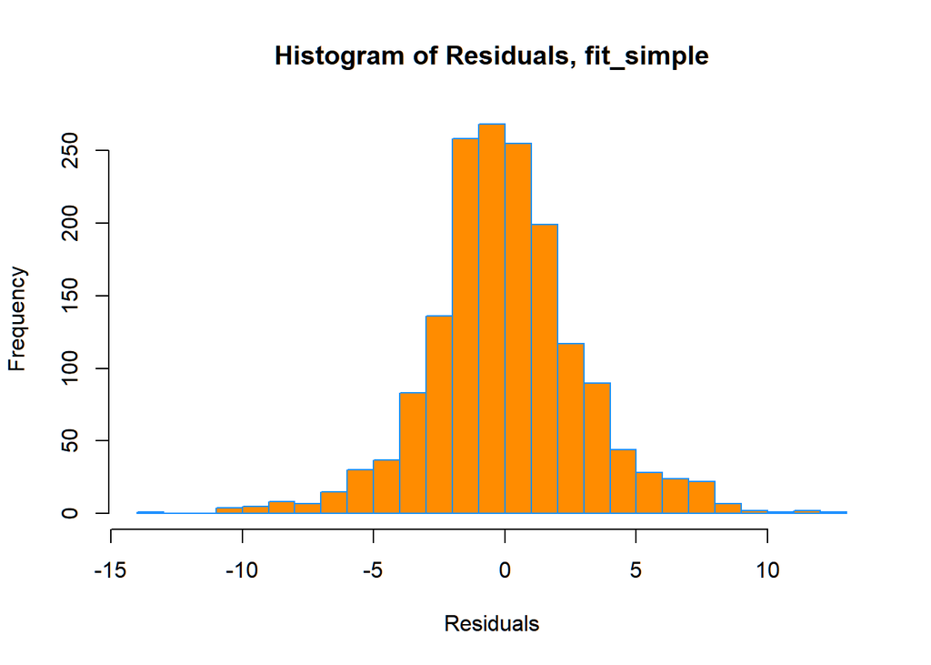

```r
hist(resid(fit_simple),
     xlab = "Residuals",
     main = "Histogram of Residuals, fit_simple",
     col = "darkorange",
     border = "dodgerblue",
     breaks = 20)
```

The histogram appears reasonably normal counter intuitively. Residuals seem to distribute evenly around $\mu = 0$.

#### Plot the Q-Q plot

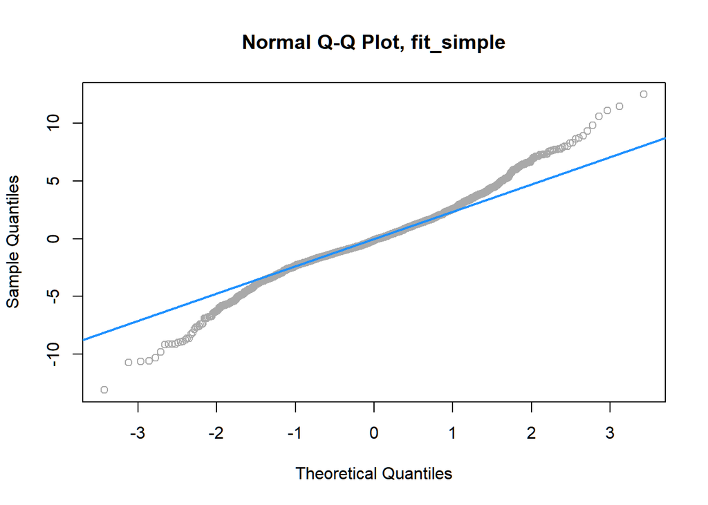

```r
qqnorm(resid(fit_simple),
       main = "Normal Q-Q Plot, fit_simple",
       col = "darkgrey")
qqline(resid(fit_simple), col = "dodgerblue", lwd = 2)
```

Q-Q plot shows residuals derivate from normal distribution when magnitude of quantile is beyond 1.5.

```r
mean(rstandard(fit_simple)[abs(rstandard(fit_simple)) > 2])
```

```
## [1] 0.4066126
```

## Outlier Diagnostics

The Q-Q plot definitely makes it seem that the normality assumptions is violated. Lets try to remove outliers and see if we can improve the normality of the residuals.

To check for outlier data points having an outside influence on our model, we will check the cooks distance of the data in our dataset.

```r
# calculating cooks distance for all the data points for the selected simple model that was trained on all the data
simple_int_mod_cd = cooks.distance(fit_simple)
sum(simple_int_mod_cd > 4/length(simple_int_mod_cd))
```

```
## [1] 121
```

There are 121 outliers that are having a high influence on our model.

Lets remove these and run the diagnostics again.

```r
fit_simple_fix = lm(life_expectancy ~ adult_mortality + Measles + BMI + polio + total_exp +
    population + thinness_1_19 + HBI + log_hiv_aids + status:adult_mortality +
    status:hepatitis + status:total_exp + status:thinness_1_19 +
    status:HBI + status:schooling + adult_mortality:BMI + adult_mortality:schooling +
    adult_mortality:log_hiv_aids + adult_mortality:log_GDP +
    alcohol:hepatitis + alcohol:Measles + alcohol:log_percent_exp +
    alcohol:log_hiv_aids + hepatitis:total_exp + hepatitis:log_percent_exp +
    BMI:population + BMI:thinness_1_19 + BMI:schooling + under_5_deaths:polio +
    under_5_deaths:HBI + under_5_deaths:schooling + polio:HBI +
    total_exp:thinness_1_19 + total_exp:HBI + diphtheria:HBI +
    diphtheria:schooling + thinness_1_19:HBI + thinness_1_19:schooling +
    thinness_1_19:log_hiv_aids + HBI:schooling + HBI:log_hiv_aids +
    schooling:log_percent_exp + schooling:log_GDP + log_percent_exp:log_GDP,
    data = data_cleaned,
    subset = simple_int_mod_cd < 4 / length(simple_int_mod_cd))

shapiro.test(resid(fit_simple_fix))
```

```
##
##  Shapiro-Wilk normality test
##
## data:  resid(fit_simple_fix)
## W = 0.9916, p-value = 1.203e-07
```

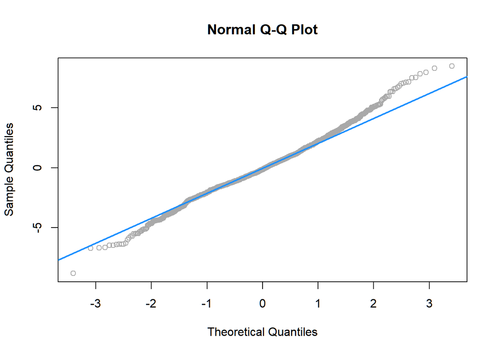

```r
qqnorm(resid(fit_simple_fix), col = "darkgrey")
qqline(resid(fit_simple_fix), col = "dodgerblue", lwd = 2)
```

```r
mean(rstandard(fit_simple)[abs(rstandard(fit_simple_fix)) > 2])
```

```
## [1] 0.1678182
```

# Results

We started from additive and interactive model with all numeric predictors and one dummy variable `status`, then performed step-wise variable selection, trimmed variables with their `p-value`, and compared models with `r-squared` and RMSE based on train/test data, and finally polished the model given issues spotted from model diagnostics. The selected model has a r squared of 0.92 which is fairly close to 1.

```r
summary(fit_simple_fix)$r.squared
```

```
## [1] 0.9200829
```

Based on the selected model, significant factors impact life expectancy are

```r
summary(fit_simple_fix)$coefficients
```

```
##                                       Estimate   Std. Error     t value
## (Intercept)                       4.278151e+01 2.290759e+00  18.6756962
## adult_mortality                   5.587362e-02 6.137372e-03   9.1038352
## Measles                           4.396671e-05 1.639243e-05   2.6821356
## BMI                               1.210165e-01 2.950120e-02   4.1020872
## polio                             7.609507e-02 1.377209e-02   5.5253083
## total_exp                        -6.253693e-01 2.004524e-01  -3.1197893
## population                       -2.383584e-10 2.380823e-09  -0.1001160
## thinness_1_19                    -2.532755e+00 2.723196e-01  -9.3006716
## HBI                               2.947333e+01 4.610519e+00   6.3926275
## log_hiv_aids                     -5.773301e+00 3.285518e-01 -17.5719665
## adult_mortality:statusDeveloping -3.122995e-02 3.865232e-03  -8.0797089
## statusDeveloped:hepatitis         1.557126e-02 1.393896e-02   1.1171032
## statusDeveloping:hepatitis        2.152665e-03 8.757068e-03   0.2458203
## total_exp:statusDeveloping        5.466288e-01 8.822376e-02   6.1959363
## thinness_1_19:statusDeveloping    2.506367e+00 2.398789e-01  10.4484639
## HBI:statusDeveloping             -1.633015e+01 3.126983e+00  -5.2223348
## statusDeveloped:schooling         1.809652e-01 2.996878e-01   0.6038458
## statusDeveloping:schooling        8.198105e-01 2.228795e-01   3.6782674
## adult_mortality:BMI               1.606638e-04 4.755961e-05   3.3781559
## adult_mortality:schooling        -3.638045e-03 3.750731e-04  -9.6995632
## adult_mortality:log_hiv_aids      8.177782e-04 3.802484e-04   2.1506422
## adult_mortality:log_GDP          -1.025793e-03 3.913828e-04  -2.6209467
## hepatitis:alcohol                 1.202989e-03 5.917081e-04   2.0330780
## Measles:alcohol                  -5.232919e-06 3.750841e-06  -1.3951320
## alcohol:log_percent_exp          -6.266127e-02 9.688616e-03  -6.4675150
## log_hiv_aids:alcohol             -1.178288e-01 1.636685e-02  -7.1992329
## total_exp:hepatitis               4.223892e-03 1.183097e-03   3.5701979
## hepatitis:log_percent_exp        -5.867431e-03 1.421819e-03  -4.1267064
## BMI:population                    6.313907e-11 9.359123e-11   0.6746259
## BMI:thinness_1_19                -6.715448e-03 1.479755e-03  -4.5382163
## BMI:schooling                    -8.899859e-03 1.903216e-03  -4.6762201
## polio:under_5_deaths             -2.837008e-05 4.160719e-05  -0.6818553
## HBI:under_5_deaths                2.352054e-02 1.362864e-02   1.7258170
## schooling:under_5_deaths         -1.325973e-03 6.832400e-04  -1.9407130
## polio:HBI                        -1.212534e-01 2.189721e-02  -5.5373915
## total_exp:thinness_1_19          -6.389278e-02 8.262116e-03  -7.7332216
## total_exp:HBI                     3.960155e-01 1.914819e-01   2.0681620
## HBI:diphtheria                    1.552480e-01 2.439567e-02   6.3637518
## schooling:diphtheria             -7.660921e-03 1.275352e-03  -6.0069079
```

[output cut: 41 more lines]

```
## HBI:under_5_deaths               8.458963e-02
## schooling:under_5_deaths         5.248328e-02
## polio:HBI                        3.628910e-08
## total_exp:thinness_1_19          1.929042e-14
## total_exp:HBI                    3.879864e-02
## HBI:diphtheria                   2.621228e-10
## schooling:diphtheria             2.377410e-09
## thinness_1_19:HBI                3.671643e-07
## thinness_1_19:schooling          1.878968e-13
## thinness_1_19:log_hiv_aids       3.752902e-02
## HBI:schooling                    1.180832e-05
## HBI:log_hiv_aids                 1.728052e-51
## schooling:log_percent_exp        3.670659e-04
## schooling:log_GDP                1.002993e-05
## log_GDP:log_percent_exp          1.144107e-04
```

# Discussion

Among above influential factors some are directly related to the economic status of a country such as `log_GDP` and `HBI`, others are indirectly related to economy such as `schooling`, `BMI`, and vaccine coverage (`polio`, `Hepatitis`, and `Measles`). Development level of a country determines the amount of resources contributed to education (`schooling`) and health care such as vaccine coverage.

Calculate the expected life expectancy using the selected model and cleaned data set, then sort the data frame by life expectancy in descending order.

```r
data_predict = data_transformed[!duplicated(data_transformed["country"]),]
data_predict = subset(data_predict, select = -c(life_expectancy))
data_fitted = data.frame(subset(data_predict, select = -c(year, percent_exp, hiv_aids, GDP, thinness_5_9, infant_deaths)))
data_fitted$life_expectancy = predict(fit_simple_fix, newdata = data_predict)
data_fitted = data_fitted[order(data_fitted$life_expectancy, decreasing = TRUE),]
kable(subset(head(data_fitted, 80), select = c(country, status, life_expectancy, log_GDP)))
```

|  | country | status | life_expectancy | log_GDP |
| --- | --- | --- | --- | --- |
| 80 | Australia | Developed | 84.95593 | 11.038346 |
| 707 | Israel | Developing | 83.67773 | 10.534303 |
| 702 | Ireland | Developed | 82.67665 | 8.622152 |
| 527 | France | Developing | 82.63378 | 10.667914 |
| 722 | Italy | Developed | 82.56741 | 10.474373 |
| 871 | Luxembourg | Developed | 82.38595 | 11.688329 |
| 567 | Germany | Developed | 81.54369 | 8.474839 |
| 1088 | Netherlands | Developed | 81.49719 | 10.862023 |
| 1218 | Portugal | Developed | 80.74260 | 7.730849 |
| 149 | Belgium | Developed | 80.55526 | 10.767208 |
| 595 | Greece | Developing | 80.51249 | 9.983859 |
| 1511 | Tunisia | Developing | 79.90469 | 8.359763 |
| 1377 | Spain | Developed | 79.85559 | 5.691954 |
| 1429 | Sweden | Developed | 79.73043 | 8.685787 |
| 414 | Cyprus | Developed | 79.72687 | 7.913844 |
| 94 | Austria | Developed | 79.43355 | 10.845887 |
| 340 | Chile | Developing | 79.32029 | 9.603556 |
| 1021 | Montenegro | Developing | 79.20740 | 8.906305 |
| 493 | Estonia | Developing | 78.18176 | 9.900556 |
| 954 | Malta | Developed | 77.92354 | 7.870520 |
| 406 | Croatia | Developed | 77.49486 | 9.508032 |
| 391 | Costa Rica | Developing | 77.25380 | 7.406979 |
| 207 | Bosnia and Herzegovina | Developing | 77.19306 | 8.555250 |
| 315 | Canada | Developing | 76.95814 | 6.299746 |
| 1567 | Ukraine | Developing | 76.80228 | 5.751487 |
| 807 | Latvia | Developed | 76.54015 | 9.663016 |
| 1203 | Poland | Developed | 76.46596 | 9.570925 |
| 764 | Kazakhstan | Developing | 76.27359 | 7.159731 |
| 1582 | Uruguay | Developing | 76.18950 | 9.725431 |
| 1135 | Panama | Developing | 76.06637 | 9.440955 |
| 33 | Algeria | Developing | 75.93807 | 6.306005 |
| 17 | Albania | Developing | 75.89440 | 8.282541 |
| 1275 | Samoa | Developing | 75.62607 | 8.337821 |
| 65 | Armenia | Developing | 75.59697 | 8.292727 |
| 1526 | Turkey | Developing | 75.49100 | 9.403208 |
| 52 | Argentina | Developing | 75.46050 | 9.412894 |
| 364 | Colombia | Developing | 75.39603 | 8.976311 |
| 1324 | Seychelles | Developing | 75.34784 | 7.351016 |
| 512 | Fiji | Developing | 75.18241 | 6.303301 |
| 248 | Bulgaria | Developed | 74.91515 | 8.968694 |
| 1483 | Tonga | Developing | 74.91353 | 8.341017 |
| 1176 | Peru | Developing | 74.74289 | 8.778253 |
| 1392 | Sri Lanka | Developing | 74.66336 | 5.946859 |
| 1164 | Paraguay | Developing | 74.64967 | 8.458042 |
| 552 | Georgia | Developing | 74.44801 | 8.396078 |
| 452 | Ecuador | Developing | 74.37312 | 8.769075 |
| 991 | Mexico | Developing | 74.35498 | 7.280888 |
| 233 | Brazil | Developing | 74.27969 | 7.112016 |
| 1092 | Nicaragua | Developing | 74.14154 | 7.588559 |
| 856 | Lithuania | Developed | 74.01883 | 9.714442 |
| 927 | Maldives | Developing | 73.67487 | 8.951083 |
| 749 | Jordan | Developing | 73.63068 | 6.146217 |
| 109 | Azerbaijan | Developing | 73.57263 | 8.973516 |
| 1313 | Serbia | Developing | 73.56119 | 4.129924 |
| 349 | China | Developing | 73.56035 | 8.946834 |
| 912 | Malaysia | Developing | 73.34802 | 9.322236 |
| 1248 | Russian Federation | Developing | 73.24461 | 9.555770 |
| 822 | Lebanon | Developing | 73.23361 | 9.007179 |
| 283 | Cabo Verde | Developing | 73.16476 | 8.168945 |
| 1233 | Romania | Developed | 73.14905 | 2.507754 |
| 737 | Jamaica | Developing | 73.10643 | 8.487918 |
| 976 | Mauritius | Developing | 73.06787 | 7.050936 |
| 1454 | Thailand | Developing | 72.92862 | 8.689775 |
| 437 | Dominican Republic | Developing | 72.82525 | 8.743323 |
| 134 | Belarus | Developing | 72.42800 | 9.026229 |
| 467 | El Salvador | Developing | 72.39007 | 8.291239 |
| 1498 | Trinidad and Tobago | Developing | 72.38321 | 9.869167 |
| 1610 | Vanuatu | Developing | 72.12042 | 8.054639 |
| 792 | Kiribati | Developing | 72.11690 | 7.429249 |
| 1404 | Suriname | Developing | 71.75302 | 9.165810 |
| 1030 | Morocco | Developing | 71.68556 | 8.056590 |
| 164 | Belize | Developing | 71.05021 | 8.487192 |
| 650 | Honduras | Developing | 70.82563 | 7.715441 |
| 610 | Guatemala | Developing | 70.73410 | 8.212775 |
| 1076 | Nepal | Developing | 70.66583 | 4.333869 |
| 676 | Indonesia | Developing | 70.64585 | 8.158114 |
| 542 | Gabon | Developing | 70.38233 | 9.179073 |
| 1597 | Uzbekistan | Developing | 70.19157 | 3.236653 |
| 1347 | Solomon Islands | Developing | 70.05249 | 3.389551 |
| 634 | Guyana | Developing | 70.01030 | 3.780164 |

Canada, Israel, and France ranks high in above table and are marked as developing, but there are no WTO definitions of `developed` and `developing` countries. Members may announce themselves as developing to gain tax and trade benefits. It’s against our common senses to treat these three countries equally as Kazakhstan or Uruguay economically. We can conclude that economic-developed countries have higher life expectancy than developing ones. Circle back to the question we asked in introduction about Nepal, the data shows no developed countries have lower life expectancy than Nepal. Unfortunately materialism defeats spiritual sanctification again. The selected model still has flaws such as heteroscedasticity and normality violation. It is definitely not the perfect answer, but countries and worldwide organizations can utilize it as a guidance on which areas resources and assets should be allocated in order to strike for greater longevity for all mankind efficiently.

## Prediction vs Explanation

The model above is most useful for prediction as it has the lowest RMSE when we used the test-train method.

So it would be most fit to use when we had data for a new country but we did not know its life expectancy. We could use the model to predict the life expectancy.

However, for explanation purposes, the extremely simple additive model still works best.

We run an exhaustive search and use the variable selection for the model with each number of predictors to get an idea of importance.

```r
library(leaps)
all_life_mod = summary(regsubsets(life_expectancy ~ ., data = data_cleaned, nvmax = 6))
all_life_mod$which
```

```
##   (Intercept) statusDeveloping adult_mortality alcohol hepatitis Measles   BMI
## 1        TRUE            FALSE           FALSE   FALSE     FALSE   FALSE FALSE
## 2        TRUE            FALSE           FALSE   FALSE     FALSE   FALSE FALSE
## 3        TRUE            FALSE            TRUE   FALSE     FALSE   FALSE FALSE
## 4        TRUE            FALSE            TRUE   FALSE     FALSE   FALSE FALSE
## 5        TRUE            FALSE            TRUE   FALSE     FALSE   FALSE FALSE
## 6        TRUE            FALSE            TRUE   FALSE     FALSE   FALSE FALSE
##   under_5_deaths polio total_exp diphtheria population thinness_1_19   HBI
## 1          FALSE FALSE     FALSE      FALSE      FALSE         FALSE FALSE
## 2          FALSE FALSE     FALSE      FALSE      FALSE         FALSE  TRUE
## 3          FALSE FALSE     FALSE      FALSE      FALSE         FALSE FALSE
## 4          FALSE FALSE     FALSE      FALSE      FALSE         FALSE  TRUE
## 5          FALSE FALSE     FALSE      FALSE      FALSE         FALSE  TRUE
## 6          FALSE FALSE     FALSE      FALSE      FALSE          TRUE  TRUE
##   schooling log_percent_exp log_hiv_aids log_GDP
## 1     FALSE           FALSE         TRUE   FALSE
## 2     FALSE           FALSE         TRUE   FALSE
## 3      TRUE           FALSE         TRUE   FALSE
## 4      TRUE           FALSE         TRUE   FALSE
## 5      TRUE            TRUE         TRUE   FALSE
## 6      TRUE            TRUE         TRUE   FALSE
```

```r
(best_r2_ind = which.max(all_life_mod$adjr2))
```

```
## [1] 6
```

Using the analysis above, we can see that if we were limited to a model of n predictors, we would pick the following predictors:

[output not shown]

Interestingly, the Developed status of a country nor its GDP are within the top few predictors of life expectancy.

But the important variables are all definitely correlated with GDP and the developed status of a nation. Using our simple model to rank models by number of variables has provided us interesting insight into what are the most important factors for governments of countries to be focused on, in order to improve the life expectancy of their people!

# Appendix

## Group Members

| Name | NetID |
| --- | --- |
| Xinlei Huang | xhuang84 |
| Mohammad Khan | mfkahn5 |
| Jaccob Mau | jcmau2 |
| Jonathan Temkin | jtemkin3 |